# Singularity Systems Inc - Interview Project

Da Lu

July/29/2019 - July/31/2019

# 1 Background

This is an NLP project.

# 2 Evaluations

1. How long does it take you to finish the project
2. The Evaluation Results (based on macro-average of all classes’ F1 scores).
3. The Source Code Review
4. Please write a report about what you find and how did you solve the problem. And we will review your report’s quality

# 3 Load Data

```r
# Read the folder names of the given 20 classes.
train_classes = list.files("C:/Users/Harry Lu's X1/Desktop/SS/data/train")

# Read the file names from all the 20 folders, record the number of files from each folder.
train_class_files = c()
train_class_numbers = rep(NA, times = length(train_classes))
for (i in 1:length(train_classes)) {
  temp_files = list.files(paste("C:/Users/Harry Lu's X1/Desktop/SS/data/train/", train_classes[i], sep = ""))
  train_class_files = c(train_class_files, temp_files)
  train_class_numbers[i] = length(temp_files)
}

# Remove helper variables.
rm(i, temp_files)
```

```r
# Create a table to record the starting index and ending index for each class.
class_start = rep(NA, times = 20)
class_end = rep(NA, times = 20)
for (i in 1:20) {
  if (i == 1) {
    class_start[i] = 1
    class_end[i] = class_start[i] + train_class_numbers[i] - 1
  }
  if (i > 1) {
    class_start[i] = class_end[i - 1] + 1
    class_end[i] = class_start[i] + train_class_numbers[i] - 1
  }
}
class_range = data.frame(train_classes, class_start, class_end)

# Remove helper variables.
rm(i, class_start, class_end)
```

```r
# Create an array of classes with the length of files.
class = c()
for (i in 1:length(train_classes)) {
  class = c(class, rep(train_classes[i], times = train_class_numbers[i]))
}
file = train_class_files

# Remove helper variables.
rm(i, train_classes, train_class_files, train_class_numbers)
```

```r
# Read the content of each files line by line.
content = rep(NA, times = length(class))
for (i in 1:length(class)) {
  temp = scan(file = paste("C:/Users/Harry Lu's X1/Desktop/SS/data/train/", class[i], "/", file[i], sep = ""), what = "character", sep = "\n")
  content[i] = list(temp)
}

# Remove helper variables.
rm(i, temp)
```

Now, we have 3 variables `class`, `file`, and `content` with the same length, and 1 table `class_range`.

- `class`: A character array, which has length 11083 and class labels on each positions.
- `file`: A character array, which has length 11083. It contains all the file names from the “train” folder.
- `content`: A list, which has length 11083. Each position contains the text content of each file line by line.
- `class_range`: A data frame, which contains all the class labels and their corresponding starting and ending index.

# 4 Clean Data

## 4.1 Sender’s Email Address

We found that the email sender would always in the line starts `From:`, and all the files’ first 7 rows would contain the key word `From:`.

```r
library(dplyr)
library(knitr)
library(ggplot2)
```

```r
# Get the sender email address from each file. If there is no sender, the value is set to "" (empty string).
sender_email = rep(NA, times = length(class))
for (i in 1:length(class)) {
  line_index = grep("From:", content[[i]][1:7])
  line_content = content[[i]][line_index]
  line_content_split = strsplit(line_content, " +")[[1]]
  email_position = grep("@", line_content_split)
  if (length(email_position) > 0) {
    email = line_content_split[email_position]
    if (length(grep("<", email)) > 0) {
      email = substr(email, 2, nchar(email) - 1)
    }
    if (length(grep("\\(", email)) > 0) {
      email = substr(email, 2, nchar(email) - 1)
    }
    if (length(grep("\\$", email)) > 0) {
      email = substr(email, 2, nchar(email))
    }
  }
  if (length(email_position) == 0) {
    email = ""
  }
  sender_email[i] = tolower(email)
}

# Remove helper variables.
rm(i, line_index, line_content, line_content_split, email_position, email)
```

```r
# Extract the email list for each class.
sender_email_class_1 = sender_email[class_range[1,2]:class_range[1,3]]
sender_email_class_2 = sender_email[class_range[2,2]:class_range[2,3]]
sender_email_class_3 = sender_email[class_range[3,2]:class_range[3,3]]
sender_email_class_4 = sender_email[class_range[4,2]:class_range[4,3]]
sender_email_class_5 = sender_email[class_range[5,2]:class_range[5,3]]
sender_email_class_6 = sender_email[class_range[6,2]:class_range[6,3]]
sender_email_class_7 = sender_email[class_range[7,2]:class_range[7,3]]
sender_email_class_8 = sender_email[class_range[8,2]:class_range[8,3]]
sender_email_class_9 = sender_email[class_range[9,2]:class_range[9,3]]
sender_email_class_10 = sender_email[class_range[10,2]:class_range[10,3]]
sender_email_class_11 = sender_email[class_range[11,2]:class_range[11,3]]
sender_email_class_12 = sender_email[class_range[12,2]:class_range[12,3]]
sender_email_class_13 = sender_email[class_range[13,2]:class_range[13,3]]
sender_email_class_14 = sender_email[class_range[14,2]:class_range[14,3]]
sender_email_class_15 = sender_email[class_range[15,2]:class_range[15,3]]
sender_email_class_16 = sender_email[class_range[16,2]:class_range[16,3]]
sender_email_class_17 = sender_email[class_range[17,2]:class_range[17,3]]
sender_email_class_18 = sender_email[class_range[18,2]:class_range[18,3]]
sender_email_class_19 = sender_email[class_range[19,2]:class_range[19,3]]
sender_email_class_20 = sender_email[class_range[20,2]:class_range[20,3]]

# Create a table with numbers of email for both the whole training dataset and every classes.
email_count = data.frame(table(data.frame(sender_email)))
email_count$Var1 = as.character(email_count$Var1)

email_count_class_1 = data.frame(table(data.frame(sender_email_class_1)))
colnames(email_count_class_1)[2] = "class_1"
email_count_class_1$Var1 = as.character(email_count_class_1$Var1)

email_count_class_2 = data.frame(table(data.frame(sender_email_class_2)))
colnames(email_count_class_2)[2] = "class_2"
email_count_class_2$Var1 = as.character(email_count_class_2$Var1)

email_count_class_3 = data.frame(table(data.frame(sender_email_class_3)))
colnames(email_count_class_3)[2] = "class_3"
email_count_class_3$Var1 = as.character(email_count_class_3$Var1)

email_count_class_4 = data.frame(table(data.frame(sender_email_class_4)))
colnames(email_count_class_4)[2] = "class_4"
email_count_class_4$Var1 = as.character(email_count_class_4$Var1)

email_count_class_5 = data.frame(table(data.frame(sender_email_class_5)))
colnames(email_count_class_5)[2] = "class_5"
email_count_class_5$Var1 = as.character(email_count_class_5$Var1)

email_count_class_6 = data.frame(table(data.frame(sender_email_class_6)))
colnames(email_count_class_6)[2] = "class_6"
email_count_class_6$Var1 = as.character(email_count_class_6$Var1)

email_count_class_7 = data.frame(table(data.frame(sender_email_class_7)))
colnames(email_count_class_7)[2] = "class_7"
email_count_class_7$Var1 = as.character(email_count_class_7$Var1)

email_count_class_8 = data.frame(table(data.frame(sender_email_class_8)))
colnames(email_count_class_8)[2] = "class_8"
email_count_class_8$Var1 = as.character(email_count_class_8$Var1)

email_count_class_9 = data.frame(table(data.frame(sender_email_class_9)))
colnames(email_count_class_9)[2] = "class_9"
email_count_class_9$Var1 = as.character(email_count_class_9$Var1)

email_count_class_10 = data.frame(table(data.frame(sender_email_class_10)))
colnames(email_count_class_10)[2] = "class_10"
email_count_class_10$Var1 = as.character(email_count_class_10$Var1)

email_count_class_11 = data.frame(table(data.frame(sender_email_class_11)))
colnames(email_count_class_11)[2] = "class_11"
email_count_class_11$Var1 = as.character(email_count_class_11$Var1)

email_count_class_12 = data.frame(table(data.frame(sender_email_class_12)))
colnames(email_count_class_12)[2] = "class_12"
email_count_class_12$Var1 = as.character(email_count_class_12$Var1)

email_count_class_13 = data.frame(table(data.frame(sender_email_class_13)))
colnames(email_count_class_13)[2] = "class_13"
email_count_class_13$Var1 = as.character(email_count_class_13$Var1)

email_count_class_14 = data.frame(table(data.frame(sender_email_class_14)))
colnames(email_count_class_14)[2] = "class_14"
email_count_class_14$Var1 = as.character(email_count_class_14$Var1)

email_count_class_15 = data.frame(table(data.frame(sender_email_class_15)))
colnames(email_count_class_15)[2] = "class_15"
email_count_class_15$Var1 = as.character(email_count_class_15$Var1)

email_count_class_16 = data.frame(table(data.frame(sender_email_class_16)))
colnames(email_count_class_16)[2] = "class_16"
email_count_class_16$Var1 = as.character(email_count_class_16$Var1)

email_count_class_17 = data.frame(table(data.frame(sender_email_class_17)))
colnames(email_count_class_17)[2] = "class_17"
email_count_class_17$Var1 = as.character(email_count_class_17$Var1)

email_count_class_18 = data.frame(table(data.frame(sender_email_class_18)))
colnames(email_count_class_18)[2] = "class_18"
email_count_class_18$Var1 = as.character(email_count_class_18$Var1)

email_count_class_19 = data.frame(table(data.frame(sender_email_class_19)))
colnames(email_count_class_19)[2] = "class_19"
email_count_class_19$Var1 = as.character(email_count_class_19$Var1)

email_count_class_20 = data.frame(table(data.frame(sender_email_class_20)))
colnames(email_count_class_20)[2] = "class_20"
email_count_class_20$Var1 = as.character(email_count_class_20$Var1)

# Join tables.
email_count = email_count %>%
  full_join(email_count_class_1, by = "Var1") %>%
  full_join(email_count_class_2, by = "Var1") %>%
  full_join(email_count_class_3, by = "Var1") %>%
  full_join(email_count_class_4, by = "Var1") %>%
  full_join(email_count_class_5, by = "Var1") %>%
  full_join(email_count_class_6, by = "Var1") %>%
  full_join(email_count_class_7, by = "Var1") %>%
  full_join(email_count_class_8, by = "Var1") %>%
  full_join(email_count_class_9, by = "Var1") %>%
  full_join(email_count_class_10, by = "Var1") %>%
  full_join(email_count_class_11, by = "Var1") %>%
  full_join(email_count_class_12, by = "Var1") %>%
  full_join(email_count_class_13, by = "Var1") %>%
  full_join(email_count_class_14, by = "Var1") %>%
  full_join(email_count_class_15, by = "Var1") %>%
  full_join(email_count_class_16, by = "Var1") %>%
  full_join(email_count_class_17, by = "Var1") %>%
  full_join(email_count_class_18, by = "Var1") %>%
  full_join(email_count_class_19, by = "Var1") %>%
  full_join(email_count_class_20, by = "Var1")
colnames(email_count)[1:2] = c("Email", "Total")

# Transform the NA value to 0 in the table.
for (i in 3:22) {
  na_position = is.na(email_count[,i])
  email_count[,i][na_position] = 0
}

# Remove helper variables.
rm(email_count_class_1, email_count_class_2, email_count_class_3, email_count_class_4, email_count_class_5, email_count_class_6, email_count_class_7, email_count_class_8, email_count_class_9, email_count_class_10, email_count_class_11, email_count_class_12, email_count_class_13, email_count_class_14, email_count_class_15, email_count_class_16, email_count_class_17, email_count_class_18, email_count_class_19, email_count_class_20)
rm(sender_email_class_1, sender_email_class_2, sender_email_class_3, sender_email_class_4, sender_email_class_5, sender_email_class_6, sender_email_class_7, sender_email_class_8, sender_email_class_9, sender_email_class_10, sender_email_class_11, sender_email_class_12, sender_email_class_13, sender_email_class_14, sender_email_class_15, sender_email_class_16, sender_email_class_17, sender_email_class_18, sender_email_class_19, sender_email_class_20)
rm(i, na_position)
```

```r
# List the table of email counts.
library(DT)
datatable(email_count)
```

|  | Email | Total | class_1 | class_2 | class_3 | class_4 | class_5 | class_6 | class_7 | class_8 | class_9 | class_10 | class_11 | class_12 | class_13 | class_14 | class_15 | class_16 | class_17 | class_18 | class_19 | class_20 |
| --- | --- | --- | --- | --- | --- | --- | --- | --- | --- | --- | --- | --- | --- | --- | --- | --- | --- | --- | --- | --- | --- | --- |
| 1 |  | 44 | 4 | 4 | 9 | 0 | 2 | 1 | 0 | 1 | 0 | 6 | 0 | 0 | 0 | 13 | 2 | 2 | 0 | 0 | 0 | 0 |
| 2 | 0005111312@mcimail.com | 3 | 0 | 0 | 0 | 0 | 0 | 0 | 0 | 0 | 1 | 0 | 0 | 0 | 0 | 0 | 0 | 0 | 2 | 0 | 0 | 0 |
| 3 | 00bjgood@leo.bsuvc.bsu.edu | 1 | 0 | 0 | 0 | 0 | 0 | 0 | 0 | 0 | 0 | 1 | 0 | 0 | 0 | 0 | 0 | 0 | 0 | 0 | 0 | 0 |
| 4 | 00mbstultz@leo.bsuvc.bsu.edu | 1 | 0 | 0 | 0 | 0 | 0 | 0 | 0 | 0 | 0 | 1 | 0 | 0 | 0 | 0 | 0 | 0 | 0 | 0 | 0 | 0 |
| 5 | 02106@ravel.udel.edu | 6 | 0 | 0 | 0 | 0 | 0 | 0 | 6 | 0 | 0 | 0 | 0 | 0 | 0 | 0 | 0 | 0 | 0 | 0 | 0 | 0 |
| 6 | 10748539@eng2.eng.monash.edu.au | 1 | 0 | 0 | 1 | 0 | 0 | 0 | 0 | 0 | 0 | 0 | 0 | 0 | 0 | 0 | 0 | 0 | 0 | 0 | 0 | 0 |
| 7 | 1605112ec400@sscl.uwo.ca | 1 | 0 | 0 | 0 | 0 | 0 | 0 | 0 | 0 | 0 | 1 | 0 | 0 | 0 | 0 | 0 | 0 | 0 | 0 | 0 | 0 |
| 8 | 18084tm@msu.edu | 7 | 0 | 0 | 0 | 0 | 0 | 0 | 0 | 0 | 0 | 0 | 0 | 0 | 0 | 0 | 7 | 0 | 0 | 0 | 0 | 0 |
| 9 | 18669@bach.udel.edu | 1 | 0 | 0 | 0 | 0 | 0 | 0 | 0 | 0 | 0 | 0 | 0 | 0 | 0 | 0 | 0 | 1 | 0 | 0 | 0 | 0 |
| 10 | 2120788@hydra.maths.unsw.edu.au | 1 | 0 | 0 | 0 | 0 | 0 | 0 | 0 | 0 | 0 | 0 | 0 | 0 | 0 | 0 | 0 | 0 | 0 | 1 | 0 | 0 |

[output cut: 5670 more lines]

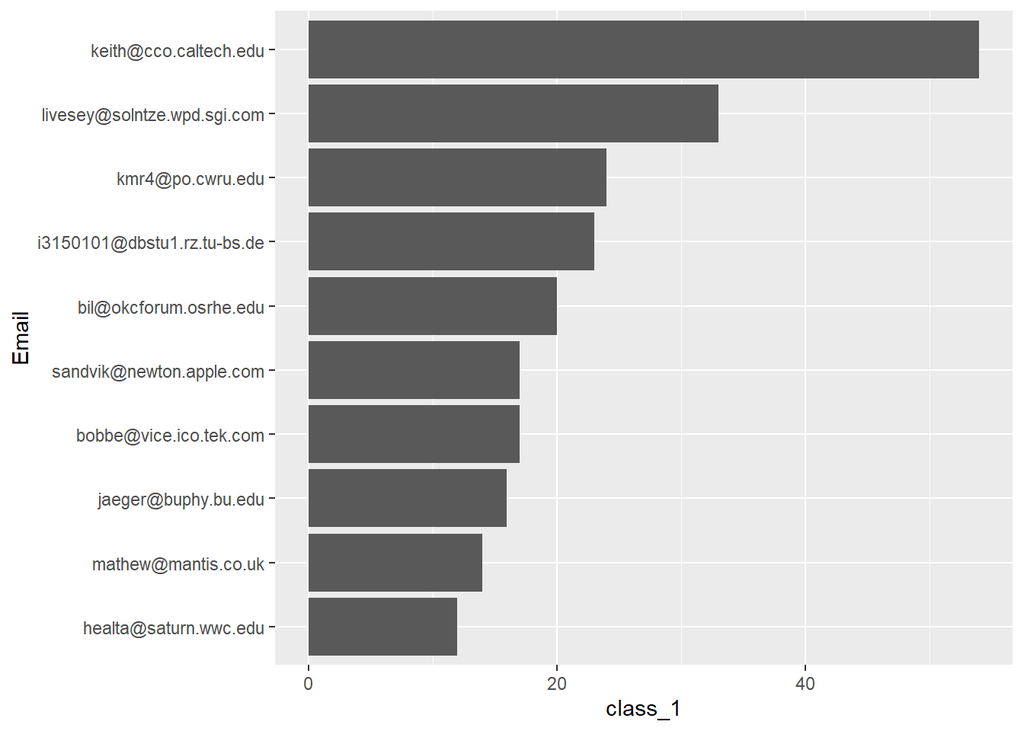

```r
# Plot the most common 10 emails of each class.
email_count %>%
  select(Email, class_1) %>%
  arrange(desc(class_1)) %>%
  top_n(10) %>%
  ggplot(aes(reorder(Email, class_1), class_1)) +
  geom_bar(stat = "identity") +
  coord_flip() +
  labs(x = "Email")
```

## 4.2 Body Text

We observe that each file (email) contains several lines of special information in the beginning. Those special information usually is the format of the email. We try to not include them for the body text part.

```r
# A function to find the start line of body text.
body_text_start_line = function(input_char) {
  colon_position = grep(":", input_char)
  colon_position = colon_position - 1:length(colon_position)
  special_info_end_line = length(which(colon_position == 0))
  body_text_start_line = special_info_end_line + 1
  return(body_text_start_line)
}
```

```r
# Get the body text of each file.
body_text = c()
for (i in 1:11083) {
  current_start_line = body_text_start_line(content[[i]])
  current_body_text = ""
  for (j in current_start_line:length(content[[i]])) {
    current_body_text = paste(current_body_text, content[[i]][j])
  }
  body_text = c(body_text, current_body_text)
}
rm(i, j, current_start_line, current_body_text)
```

```r
# Get the body file of each class.
class_body_text = c()
for (i in 1:20) {
  current_class_body_text = ""
  for (j in class_range[i,2]:class_range[i,3]) {
    current_class_body_text = paste(current_class_body_text, body_text[j])
  }
  class_body_text = c(class_body_text, current_class_body_text)
}
rm(i, j, current_class_body_text)
```

Now, we have the body text for each class, and we need to write a function to remove all the unnecessary punctuation. The function would remove those characters in the following order:

- `"`
- `(`, `)`
- `<`, `>`
- `,`
- `.` at the end (only at the end)
- `-` at the end (only at the end)

```r
clean_word = function(input_char) {
  # Remove `"`
  while (length(grep("\"", input_char)) > 0) {
    punc_position = gregexpr("\"", input_char)[[1]][1]  # Take the first `"` if there are multiple
    input_char = paste(substr(input_char, 1, punc_position - 1),
                       substr(input_char, punc_position + 1, nchar(input_char)),
                       sep = "")
  }

  # Remove `(`
  while (length(grep("\\(", input_char)) > 0) {
    punc_position = gregexpr("\\(", input_char)[[1]][1]
    input_char = paste(substr(input_char, 1, punc_position - 1),
                       substr(input_char, punc_position + 1, nchar(input_char)),
                       sep = "")
  }

  # Remove `)`
  while (length(grep("\\)", input_char)) > 0) {
    punc_position = gregexpr("\\)", input_char)[[1]][1]
    input_char = paste(substr(input_char, 1, punc_position - 1),
                       substr(input_char, punc_position + 1, nchar(input_char)),
                       sep = "")
  }

  # Remove `<`
  while (length(grep("<", input_char)) > 0) {
    punc_position = gregexpr("<", input_char)[[1]][1]
    input_char = paste(substr(input_char, 1, punc_position - 1),
                       substr(input_char, punc_position + 1, nchar(input_char)),
                       sep = "")
  }
  # Remove `>`
  while (length(grep(">", input_char)) > 0) {
    punc_position = gregexpr(">", input_char)[[1]][1]
    input_char = paste(substr(input_char, 1, punc_position - 1),
                       substr(input_char, punc_position + 1, nchar(input_char)),
                       sep = "")
  }

  # Remove `,`
  while (length(grep(",", input_char)) > 0) {
    punc_position = gregexpr(",", input_char)[[1]][1]
    input_char = paste(substr(input_char, 1, punc_position - 1),
                       substr(input_char, punc_position + 1, nchar(input_char)),
                       sep = "")
  }

  # Remove all the `.` at the end of the string
  while (length(grep("\\.", input_char)) > 0) {
    if (substr(input_char, nchar(input_char), nchar(input_char)) == ".") {
      input_char = substr(input_char, 1, nchar(input_char) - 1)
    }
    if (substr(input_char, nchar(input_char), nchar(input_char)) != ".") {
      break;
    }
  }

  # Remove all the `-` at the end of the string
  while (length(grep("-", input_char)) > 0) {
    if (substr(input_char, nchar(input_char), nchar(input_char)) == "-") {
      input_char = substr(input_char, 1, nchar(input_char) - 1)
    }
    if (substr(input_char, nchar(input_char), nchar(input_char)) != "-") {
      break;
    }
  }

  return(input_char)
}
```

# 5 test

```r
a = body_text[1]
a2 = strsplit(a, split = " +")[[1]]
a3 = rep(NA, times = length(a2))
for (i in 1:length(a3)) {
  a3[i] = a2[i] %>% clean_word()
}
head(a3)
```

```
## [1] ""          "Atheist"   "Resources" "Addresses" "of"        "Atheist"
```

```r
"|"
```

```
## [1] "|"
```

```r
"_"
```

```
## [1] "_"
```